# H2O Workshop

Airlines Dataframe

## Requirements

For compatibility with H2O:

1. Operating Systems:
- Windows 7 or later
- OS X 10.9 or later
- Ubuntu 12.04
- RHEL/CentOS 6 or later
2. Languages:
- Scala (2.10 or later), R (3 or later), and Python (2.7.x, 3.5.x, 3.6.x) are not required to use H2O unless you want to use H2O in those environments.
- Java is always required. Supported versions include:
  - Java 7 or later. Note: Java 9 is released, but is not currently supported.
- To build H2O or run H2O tests, the 64-bit JDK is required.
- To run the H2O binary using either the command line, R, or Python packages, only 64-bit JRE is required.
3. Browser: An internet browser is required to use H2O’s web UI, Flow.
- Latest version of Chrome, Firefox, Safari, or Internet Explorer.

### About H2O

H2O is fast, scalable, open-source machine learning and deep learning. Advanced algorithms such as deep learning, boosting, and bagging ensembles are built-in.

[Download H2O](https://www.h2o.ai/h2o/) to do some machine learning.

[Documentation](http://docs.h2o.ai/h2o/latest-stable/h2o-docs/index.html).

## Set your environment

```r
# Install snippet
# source('install.R')

library(h2o)
h2o.init()
```

```
##  Connection successful!
##
## R is connected to the H2O cluster:
##     H2O cluster uptime:         43 minutes 1 seconds
##     H2O cluster timezone:       Europe/Madrid
##     H2O data parsing timezone:  UTC
##     H2O cluster version:        3.18.0.1
##     H2O cluster version age:    11 days
##     H2O cluster name:           H2O_started_from_R_Beardicion_vpc718
##     H2O cluster total nodes:    1
##     H2O cluster total memory:   3.42 GB
##     H2O cluster total cores:    4
##     H2O cluster allowed cores:  4
##     H2O cluster healthy:        TRUE
##     H2O Connection ip:          localhost
##     H2O Connection port:        54321
##     H2O Connection proxy:       NA
##     H2O Internal Security:      FALSE
##     H2O API Extensions:         XGBoost, Algos, AutoML, Core V3, Core V4
##     R Version:                  R version 3.4.3 (2017-11-30)
```

```r
# h2o.clusterInfo()
```

## Data wrangling

[Data information](http://stat-computing.org/dataexpo/2009/the-data.html)

Prepare your data for modelling.

```r
# Dataset
# https://archive.ics.uci.edu/ml/datasets/Occupancy+Detection+

flights.hex <- h2o.importFile(path = 'flight_data/allyears2k.csv',
                     destination_frame = 'flights.hex')
flights.hex[1:5, ]
```

```
##   Year Month DayofMonth DayOfWeek DepTime CRSDepTime ArrTime CRSArrTime
## 1 1987    10         14         3     741        730     912        849
## 2 1987    10         15         4     729        730     903        849
## 3 1987    10         17         6     741        730     918        849
## 4 1987    10         18         7     729        730     847        849
## 5 1987    10         19         1     749        730     922        849
##   UniqueCarrier FlightNum TailNum ActualElapsedTime CRSElapsedTime AirTime
## 1            PS      1451      NA                91             79     NaN
## 2            PS      1451      NA                94             79     NaN
## 3            PS      1451      NA                97             79     NaN
## 4            PS      1451      NA                78             79     NaN
## 5            PS      1451      NA                93             79     NaN
##   ArrDelay DepDelay Origin Dest Distance TaxiIn TaxiOut Cancelled
## 1       23       11    SAN  SFO      447    NaN     NaN         0
## 2       14       -1    SAN  SFO      447    NaN     NaN         0
```

[output cut: 17 more lines]

```r
summary(flights.hex, exact_quantiles=TRUE)
```

```
##  Year           Month            DayofMonth     DayOfWeek
##  Min.   :1987   Min.   : 1.000   Min.   : 1.0   Min.   :1.000
##  1st Qu.:1992   1st Qu.: 1.000   1st Qu.: 6.0   1st Qu.:2.000
##  Median :1998   Median : 1.000   Median :14.0   Median :4.000
##  Mean   :1998   Mean   : 1.409   Mean   :14.6   Mean   :3.821
##  3rd Qu.:2003   3rd Qu.: 1.000   3rd Qu.:23.0   3rd Qu.:5.000
##  Max.   :2008   Max.   :10.000   Max.   :31.0   Max.   :7.000
##
##  DepTime        CRSDepTime     ArrTime        CRSArrTime     UniqueCarrier
##  Min.   :   1   Min.   :   0   Min.   :   1   Min.   :   0   US:18729
##  1st Qu.: 929   1st Qu.: 910   1st Qu.:1118   1st Qu.:1109   UA: 9434
##  Median :1330   Median :1320   Median :1527   Median :1516   WN: 6170
##  Mean   :1346   Mean   :1313   Mean   :1505   Mean   :1485   HP: 3451
##  3rd Qu.:1735   3rd Qu.:1720   3rd Qu.:1917   3rd Qu.:1903   PS: 3212
##  Max.   :2400   Max.   :2359   Max.   :2400   Max.   :2359   DL:  935
##  NA's   :1086                  NA's   :1195
##  FlightNum        TailNum                 ActualElapsedTime CRSElapsedTime
##  Min.   :   1.0   UNKNOW          :  179  Min.   : 16.0     Min.   : 17
##  1st Qu.: 204.0   000000          :  124  1st Qu.: 71.0     1st Qu.: 71
##  Median : 557.0   <0xE4>NKNO<0xE6>:  114  Median :101.0     Median :102
##  Mean   : 818.8   0               :   66  Mean   :124.8     Mean   :125
##  3rd Qu.:1242.0   N912UA          :   59  3rd Qu.:151.0     3rd Qu.:151
##  Max.   :3949.0   N316AW          :   56  Max.   :475.0     Max.   :437
##                   NA              :16024  NA's   :1195      NA's   :13
##  AirTime         ArrDelay          DepDelay         Origin    Dest
##  Min.   : 14.0   Min.   :-63.000   Min.   :-16.00   DEN:3558  PHX:9317
##  1st Qu.: 61.0   1st Qu.: -6.000   1st Qu.: -2.00   PIT:3241  PHL:4482
##  Median : 91.0   Median :  2.000   Median :  1.00   ORD:2246  PIT:3020
##  Mean   :114.3   Mean   :  9.317   Mean   : 10.01   BUR:2021  ORD:2103
##  3rd Qu.:140.0   3rd Qu.: 14.000   3rd Qu.: 10.00   CLT:1781  CLT:1542
##  Max.   :402.0   Max.   :475.000   Max.   :473.00   PHL:1632  DEN:1470
##  NA's   :16649   NA's   :1195      NA's   :1086
##  Distance         TaxiIn            TaxiOut          Cancelled
##  Min.   :  11.0   Min.   :  0.000   Min.   :  0.00   Min.   :0.00000
##  1st Qu.: 326.0   1st Qu.:  3.000   1st Qu.:  9.00   1st Qu.:0.00000
##  Median : 541.0   Median :  5.000   Median : 12.00   Median :0.00000
##  Mean   : 730.2   Mean   :  5.381   Mean   : 14.17   Mean   :0.02469
##  3rd Qu.: 920.0   3rd Qu.:  6.000   3rd Qu.: 16.00   3rd Qu.:0.00000
##  Max.   :3365.0   Max.   :128.000   Max.   :254.00   Max.   :1.00000
##  NA's   :35       NA's   :16026     NA's   :16024
```

[output cut: 9 more lines]

```
##  Min.   :  0.000   Min.   : 0.00000   Min.   :  0.00    YES:24441
##  1st Qu.:  0.000   1st Qu.: 0.00000   1st Qu.:  0.00    NO :19537
##  Median :  0.000   Median : 0.00000   Median :  0.00
##  Mean   :  4.855   Mean   : 0.01702   Mean   :  7.62
##  3rd Qu.:  0.000   3rd Qu.: 0.00000   3rd Qu.:  0.00
##  Max.   :323.000   Max.   :14.00000   Max.   :373.00
##  NA's   :35045     NA's   :35045      NA's   :35045
##  IsDepDelayed
##  YES:23091
##  NO :20887
##
##
##
##
##
```

Quantiles and histograms

- Quantile: A sorted sample is divided into equal-sized, adjacent, subgroups. The quartiles are the 25, 50, and 75 quantiles. The percentiles are quantiles that divide a distribution into 100 equal parts. The median is the 50 quantile.

```r
quantile(x =  flights.hex$ArrDelay, na.rm = TRUE)
```

```
##    0.1%      1%     10%     25%   33.3%     50%   66.7%     75%     90%
## -39.000 -26.000 -13.000  -6.000  -3.000   2.000   9.000  14.000  37.000
##     99%   99.9%
## 132.000 277.218
```

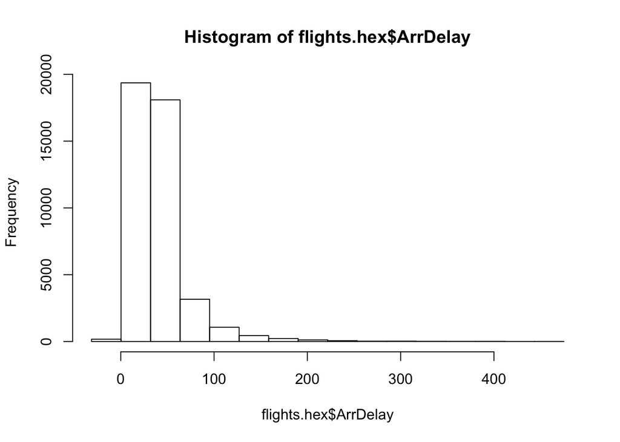

```r
h2o.hist(flights.hex$ArrDelay)
```